# Atividades de ML3

Esley Bonomo

4/22/2020

# Atividades

## Exercícios Computacionais

```r
#install.packages("varhandle")
#install.packages("fastDummies")
#install.packages("e1071")
#install.packages("ROCR")
```

### Exercício 1

Considere o conjunto de dados iris, amplamente conhecido e usado como exemplo em diversos livros de aprendizagem de máquina. Esse conjunto já vem incorporado em diversos pacotes das linguagens R e Python, de acordo com

Linguagem R: library(datasets) Linguagem Python: from sklearn import datasets

A partir do conjunto de dados carregado capture somente os dados relacionados com a classe virginica, que consiste em uma espécie de uma planta (flor). O objetivo desse exercício é construir um classificador binário a partir de um modelo de regressão logística, permitindo verificar se uma espécie a ser testada é ou não do tipo virginica. Isso significa que um pré-processamento deve ser realizado sobre o dataset iris a fim de obtermos apenas duas classes (e.g., 0 -> não é virginica e 1 -> é virginica).

As variáveis explanatórias desse conhecido dataset são: • Petal.Length: comprimento da pétala da flor • Petal.Width: largura da pétala da flor • Sepal.Length: comprimento da sépala da flor • Sepal.Width: largura da sépala da flor

1. Realize o pré-processamento necessário para extração dos dados relacionados à classe virginica.

```r
library(datasets)
library(varhandle)
library(tidyverse)
library(fastDummies)
library(caret)
```

2. Faça a análise de dados das variáveis explanatórias para o conjunto de dados.

```r
summary(iris)
```

```
##   Sepal.Length    Sepal.Width     Petal.Length    Petal.Width
##  Min.   :4.300   Min.   :2.000   Min.   :1.000   Min.   :0.100
##  1st Qu.:5.100   1st Qu.:2.800   1st Qu.:1.600   1st Qu.:0.300
##  Median :5.800   Median :3.000   Median :4.350   Median :1.300
##  Mean   :5.843   Mean   :3.057   Mean   :3.758   Mean   :1.199
##  3rd Qu.:6.400   3rd Qu.:3.300   3rd Qu.:5.100   3rd Qu.:1.800
##  Max.   :7.900   Max.   :4.400   Max.   :6.900   Max.   :2.500
##        Species
##  setosa    :50
##  versicolor:50
##  virginica :50
##
##
##
```

```r
all_species <- data.frame(Species = iris$Species)
binary_species <- dummy_cols(all_species, "Species", remove_selected_columns = TRUE)

Species <- binary_species %>% select(Species_virginica)
dataset <- data.frame(iris$Sepal.Length, iris$Sepal.Width, iris$Petal.Length, iris$Petal.Width, Species=Species$Species_virginica)

cols <- c("Species")
dataset[cols] <- lapply(dataset[cols], factor)
```

3. Realize a divisão do conjunto de treino e teste em 90/10.

```r
indices_treinamento <- createDataPartition(dataset$Species, p = 0.9, list = FALSE)
dados_treinamento <-dataset[indices_treinamento,]
dados_teste <- dataset[-indices_treinamento,]
```

4. Para reprodução dos resultados use o set.seed(12)

```r
set.seed(12)
```

5. Forneça visualizações de dispersão e densidades das variáveis explanatórias de treino e as classes.

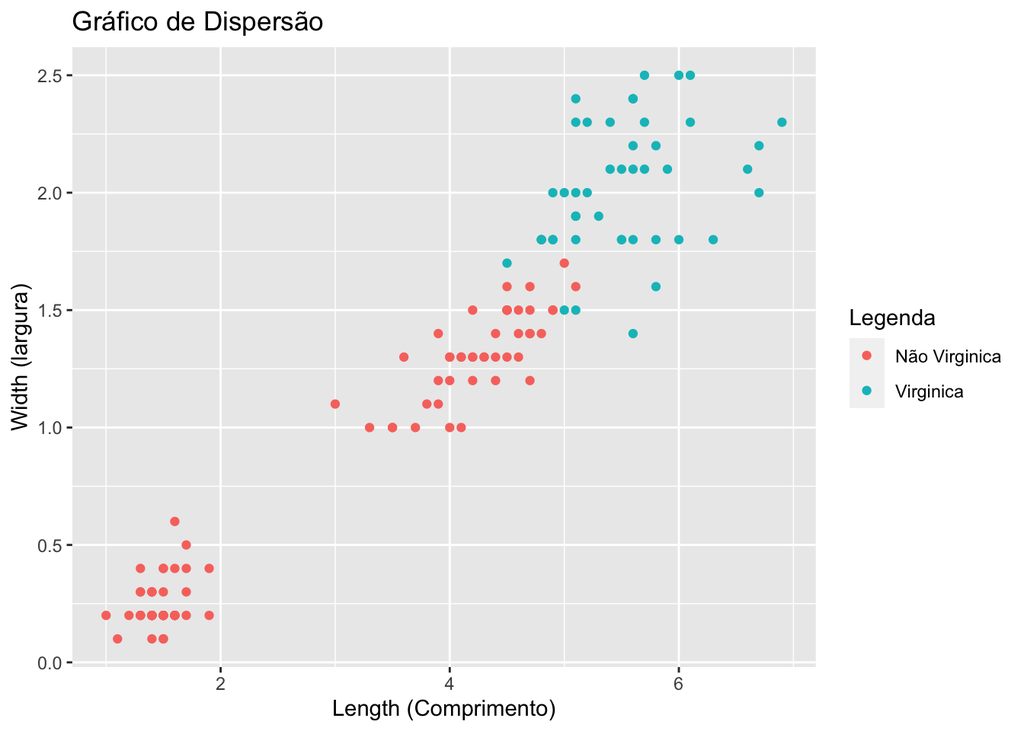

```r
dados_treinamento %>%
ggplot(aes(x = iris.Petal.Length, y = iris.Petal.Width, color=Species)) +
  geom_point() +
  scale_color_discrete(name = "Legenda", labels = c("Não Virginica","Virginica"))+
  ylab('Width (largura)') +
  xlab('Length (Comprimento)') +
  ggtitle("Gráfico de Dispersão")
```

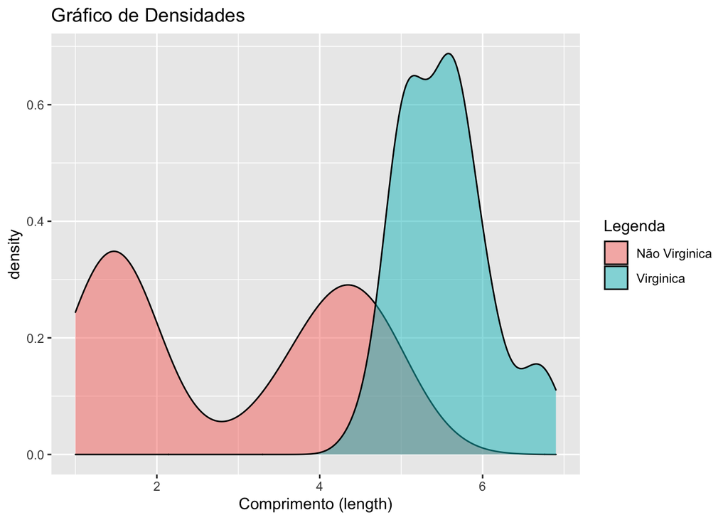

```r
dados_treinamento %>%
ggplot(aes(x=iris.Petal.Length, fill= Species)) +
  geom_density(alpha=.5) +
  xlab('Comprimento (length)') +
  scale_fill_discrete(name = "Legenda", labels = c("Não Virginica","Virginica")) +
  ggtitle("Gráfico de Densidades")
```

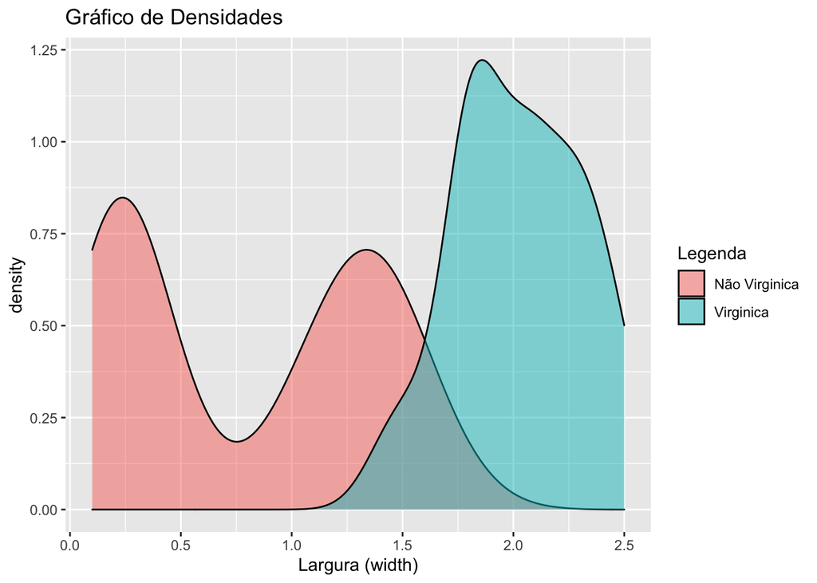

```r
dados_treinamento %>%
  ggplot(aes(x=dados_treinamento$iris.Petal.Width, fill= Species)) +
  geom_density(alpha=.5) +
  xlab('Largura (width)') +
  scale_fill_discrete(name = "Legenda", labels = c("Não Virginica","Virginica")) +
  ggtitle("Gráfico de Densidades")
```

```r
feature_dataframe <- dados_treinamento[,1:4]
matrix_corr_features <- cor(feature_dataframe)
matrix_corr_features
```

```
##                   iris.Sepal.Length iris.Sepal.Width iris.Petal.Length
## iris.Sepal.Length         1.0000000       -0.1419630         0.8732052
## iris.Sepal.Width         -0.1419630        1.0000000        -0.4427197
## iris.Petal.Length         0.8732052       -0.4427197         1.0000000
## iris.Petal.Width          0.8207347       -0.3695657         0.9612703
##                   iris.Petal.Width
## iris.Sepal.Length        0.8207347
## iris.Sepal.Width        -0.3695657
## iris.Petal.Length        0.9612703
## iris.Petal.Width         1.0000000
```

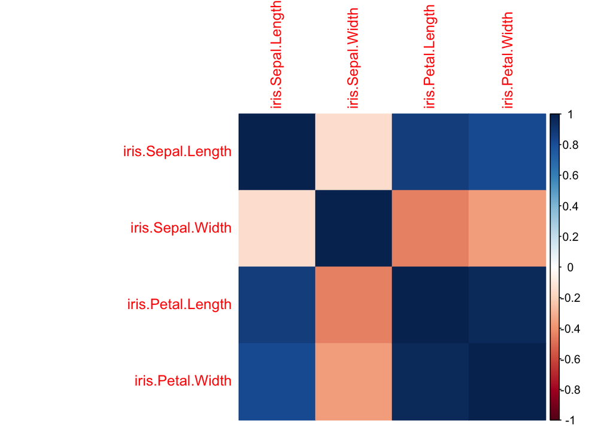

```r
corrplot::corrplot(matrix_corr_features, method = 'color')
```

6. Construa e treine o modelo preditivo de ML baseado em regressão logística

```r
eq <- " Species ~ ."
eq <- as.formula(eq)
eq
```

```
## Species ~ .
```

```r
modelo_ML_logistic <- glm(eq, data = dados_treinamento, family = 'binomial')
modelo_ML_logistic
```

```
##
## Call:  glm(formula = eq, family = "binomial", data = dados_treinamento)
##
## Coefficients:
##       (Intercept)  iris.Sepal.Length   iris.Sepal.Width  iris.Petal.Length
##           -42.446             -2.469             -6.647              9.404
##  iris.Petal.Width
##            18.205
##
## Degrees of Freedom: 134 Total (i.e. Null);  130 Residual
## Null Deviance:       171.9
## Residual Deviance: 11.89     AIC: 21.89
```

7. Faça a síntese do modelo e interprete os seus resultados

```r
summary(modelo_ML_logistic)
```

```
##
## Call:
## glm(formula = eq, family = "binomial", data = dados_treinamento)
##
## Deviance Residuals:
##      Min        1Q    Median        3Q       Max
## -2.01028  -0.00079   0.00000   0.00048   1.77685
##
## Coefficients:
##                   Estimate Std. Error z value Pr(>|z|)
## (Intercept)        -42.446     25.896  -1.639   0.1012
## iris.Sepal.Length   -2.469      2.394  -1.031   0.3024
## iris.Sepal.Width    -6.647      4.516  -1.472   0.1410
## iris.Petal.Length    9.404      4.750   1.980   0.0477 *
## iris.Petal.Width    18.205      9.834   1.851   0.0641 .
## ---
## Signif. codes:  0 '***' 0.001 '**' 0.01 '*' 0.05 '.' 0.1 ' ' 1
##
## (Dispersion parameter for binomial family taken to be 1)
##
##     Null deviance: 171.859  on 134  degrees of freedom
## Residual deviance:  11.894  on 130  degrees of freedom
## AIC: 21.894
##
## Number of Fisher Scoring iterations: 12
```

8. Encontre as variáveis explanatórias mais relevantes para o modelo.

```r
modelo_ML_logistic_2 <- glm(Species ~ iris.Petal.Width + iris.Petal.Length, data = dados_treinamento, family = 'binomial')
summary(modelo_ML_logistic_2)
```

```
##
## Call:
## glm(formula = Species ~ iris.Petal.Width + iris.Petal.Length,
##     family = "binomial", data = dados_treinamento)
##
## Deviance Residuals:
##      Min        1Q    Median        3Q       Max
## -1.72510  -0.01606   0.00000   0.00555   1.88580
##
## Coefficients:
##                   Estimate Std. Error z value Pr(>|z|)
## (Intercept)        -44.404     13.673  -3.247  0.00116 **
## iris.Petal.Width    10.227      3.773   2.710  0.00672 **
## iris.Petal.Length    5.650      2.303   2.453  0.01417 *
## ---
## Signif. codes:  0 '***' 0.001 '**' 0.01 '*' 0.05 '.' 0.1 ' ' 1
##
## (Dispersion parameter for binomial family taken to be 1)
##
##     Null deviance: 171.859  on 134  degrees of freedom
## Residual deviance:  20.431  on 132  degrees of freedom
## AIC: 26.431
##
## Number of Fisher Scoring iterations: 10
```

9. Faça as predições para os dados de teste e avalie os resultados

```r
previsao_teste <- predict(modelo_ML_logistic_2, dados_teste, type="response")
previsao_teste <- round(as.numeric(previsao_teste))
previsao_teste <- as.factor(previsao_teste)
dados_teste_fatores = as.factor(dados_teste$Species)
previsao_teste_data <- data.frame(previsao_teste, dados_teste_fatores)

confusionMatrix(data = previsao_teste, reference = dados_teste_fatores, positive = "1")
```

```
## Confusion Matrix and Statistics
##
##           Reference
## Prediction  0  1
##          0 10  0
##          1  0  5
##
##                Accuracy : 1
##                  95% CI : (0.782, 1)
##     No Information Rate : 0.6667
##     P-Value [Acc > NIR] : 0.002284
##
##                   Kappa : 1
##
##  Mcnemar's Test P-Value : NA
##
##             Sensitivity : 1.0000
##             Specificity : 1.0000
##          Pos Pred Value : 1.0000
##          Neg Pred Value : 1.0000
##              Prevalence : 0.3333
##          Detection Rate : 0.3333
##    Detection Prevalence : 0.3333
##       Balanced Accuracy : 1.0000
##
##        'Positive' Class : 1
##
```

10. A partir dos novos dados de entrada colocados abaixo, realize as classificações com o modelo

```r
flor1 <- data.frame(iris.Sepal.Length=6.4, iris.Sepal.Width=2.8, iris.Petal.Length=4.6, iris.Petal.Width=1.8)
flor2 <- data.frame(iris.Sepal.Length=6.3, iris.Sepal.Width=2.5, iris.Petal.Length=4.1, iris.Petal.Width=1.7)

pred_flor1 <- predict(modelo_ML_logistic, flor1, type = 'response')
pred_flor1
```

```
##         1
## 0.3026231
```

```r
pred_flor2 <- predict(modelo_ML_logistic, flor2, type = 'response')
pred_flor2
```

```
##           1
## 0.005963179
```

### Exercício 2

```r
#Carregando as libs
library(datasets)
library(varhandle)
library(tidyverse)
library(fastDummies)
library(caret)
library(e1071)
```

Considere o desenvolvimento do modelo de classificação do Exercício Computacional 1 - obtenha a matriz de confusão do classificador. O ponto chave aqui é realizar a interpretação dos resultados obtidos.

```r
dataset = iris

all_species <- data.frame(Species = iris$Species)
binary_species <- dummy_cols(all_species, "Species", remove_selected_columns = TRUE)

Species <- binary_species %>% select(Species_virginica)

dataset <- data.frame(dataset$Sepal.Length, dataset$Sepal.Width, dataset$Petal.Length, dataset$Petal.Width, Species=Species$Species_virginica)

cols <- c("Species")

dataset[cols] <- lapply(dataset[cols], factor)

#Seek em 12
set.seed(12)

indices_treinamento <- createDataPartition(dataset$Species, p = 0.9, list = FALSE)
#Separando dados
dados_treinamento <-dataset[indices_treinamento,]
dados_teste <- dataset[-indices_treinamento,]

previsao_ml <- function (dados_treinamento, dados_teste, equation) {
  ml_log <- glm(equation, data = dados_treinamento, family = 'binomial')

  #Previsão de teste
  previsao_teste <- predict(ml_log, dados_teste, type="response")
  previsao_teste <- round(as.numeric(previsao_teste))
  previsao_teste <- as.factor(previsao_teste)
  dados_teste_fatores = as.factor(dados_teste$Species)
  previsao_teste_data <- data.frame(previsao_teste, dados_teste_fatores)
  confusionMatrix(data = previsao_teste, reference = dados_teste_fatores, positive = "1")
}

#Modelos logistico de todas espécies
equation <- as.formula("Species ~ .")
previsao_ml(dados_treinamento, dados_teste, equation)
```

```
## Confusion Matrix and Statistics
##
##           Reference
## Prediction 0 1
##          0 8 0
##          1 2 5
##
##                Accuracy : 0.8667
##                  95% CI : (0.5954, 0.9834)
##     No Information Rate : 0.6667
##     P-Value [Acc > NIR] : 0.07936
##
##                   Kappa : 0.7273
##
##  Mcnemar's Test P-Value : 0.47950
##
##             Sensitivity : 1.0000
##             Specificity : 0.8000
##          Pos Pred Value : 0.7143
##          Neg Pred Value : 1.0000
##              Prevalence : 0.3333
##          Detection Rate : 0.3333
##    Detection Prevalence : 0.4667
##       Balanced Accuracy : 0.9000
##
##        'Positive' Class : 1
##
```

```r
#Modelos logistico de todas espécies
equation <- as.formula("Species ~ dataset.Petal.Width + dataset.Petal.Length")
previsao_ml(dados_treinamento, dados_teste, equation)
```

```
## Confusion Matrix and Statistics
##
##           Reference
## Prediction 0 1
##          0 9 0
##          1 1 5
##
##                Accuracy : 0.9333
##                  95% CI : (0.6805, 0.9983)
##     No Information Rate : 0.6667
##     P-Value [Acc > NIR] : 0.01941
##
##                   Kappa : 0.8571
##
##  Mcnemar's Test P-Value : 1.00000
##
##             Sensitivity : 1.0000
##             Specificity : 0.9000
##          Pos Pred Value : 0.8333
##          Neg Pred Value : 1.0000
##              Prevalence : 0.3333
##          Detection Rate : 0.3333
##    Detection Prevalence : 0.4000
##       Balanced Accuracy : 0.9500
##
##        'Positive' Class : 1
##
```

### Exercício 3

Uma instituição financeira nos forneceu um conjunto de dados relacionados à créditos financeiros presentes no banco de dados da instituição. A instituição está trabalhando em um projeto de ciência de dados para previsão de risco de crédito. Nós iremos participar de uma fase específica desse projeto com o objetivo de construir um classificador, que possa auxiliar na análise de risco de crédito de diversos clientes da instituição. O modelo de ML (i.e., classificador) deve prever se um determinado cliente deve ou não receber créditos de produtos financeiros ofertados pela instituição. Isso significa que teremos acesso a um conjunto de dados com informações diversas sobre inúmeros clientes da instituição. O conjunto de dados consiste em vinte (20) variáveis explanatórias que consistem em informações diversas sobre os clientes incluindo: duração e tamanho do crédito, indicadores de saldo e operações financeiras, além de dados dos clientes como idade, dependentes, emprego e até contatos como telefone. Tais informações são apresentadas com codificação que são processadas pela instituição para posteriores interpretações. Com isso, nossa tarefa consiste em lidar com os dados codificados e a variável de saída credit.rating, que indica o estado de aprovação (1) ou desaprovação (0) de crédito para cada dados de treinamento (registro) do dataset. Os pacotes listados abaixo serão fundamentais para as questões avaliativas: • library(caret) • library(ROCR) • library(e1071)

```r
library(caret)
library(ROCR)
library(e1071)
```

1. Realize a importação do arquivo .csv fornecido para o RStudio

```r
dataset_credito <- read.csv("dataset/credit_dataset.csv", header = TRUE, sep = ',')
```

2. Faça a análise exploratória do dataset e verifique: ∗ i) a necessidade de normalização dos dados ∗ ii) conversão para fatores

```r
summary(dataset_credito)
```

```
##  credit.rating account.balance credit.duration.months
##  Min.   :0.0   Min.   :1.000   Min.   : 4.0
##  1st Qu.:0.0   1st Qu.:1.000   1st Qu.:12.0
##  Median :1.0   Median :2.000   Median :18.0
##  Mean   :0.7   Mean   :2.183   Mean   :20.9
##  3rd Qu.:1.0   3rd Qu.:3.000   3rd Qu.:24.0
##  Max.   :1.0   Max.   :3.000   Max.   :72.0
##  previous.credit.payment.status credit.purpose  credit.amount      savings
##  Min.   :1.000                  Min.   :1.000   Min.   :  250   Min.   :1.000
##  1st Qu.:2.000                  1st Qu.:2.000   1st Qu.: 1366   1st Qu.:1.000
##  Median :2.000                  Median :3.000   Median : 2320   Median :1.000
##  Mean   :2.292                  Mean   :2.965   Mean   : 3271   Mean   :1.874
##  3rd Qu.:3.000                  3rd Qu.:4.000   3rd Qu.: 3972   3rd Qu.:3.000
##  Max.   :3.000                  Max.   :4.000   Max.   :18424   Max.   :4.000
##  employment.duration installment.rate marital.status    guarantor
##  Min.   :1.000       Min.   :1.000    Min.   :1.000   Min.   :1.000
##  1st Qu.:2.000       1st Qu.:2.000    1st Qu.:1.000   1st Qu.:1.000
##  Median :2.000       Median :3.000    Median :3.000   Median :1.000
##  Mean   :2.446       Mean   :2.973    Mean   :2.372   Mean   :1.093
##  3rd Qu.:4.000       3rd Qu.:4.000    3rd Qu.:3.000   3rd Qu.:1.000
##  Max.   :4.000       Max.   :4.000    Max.   :4.000   Max.   :2.000
##  residence.duration current.assets       age        other.credits
##  Min.   :1.000      Min.   :1.000   Min.   :19.00   Min.   :1.000
##  1st Qu.:2.000      1st Qu.:1.000   1st Qu.:27.00   1st Qu.:2.000
##  Median :3.000      Median :2.000   Median :33.00   Median :2.000
##  Mean   :2.845      Mean   :2.358   Mean   :35.54   Mean   :1.814
##  3rd Qu.:4.000      3rd Qu.:3.000   3rd Qu.:42.00   3rd Qu.:2.000
##  Max.   :4.000      Max.   :4.000   Max.   :75.00   Max.   :2.000
##  apartment.type   bank.credits     occupation      dependents
##  Min.   :1.000   Min.   :1.000   Min.   :1.000   Min.   :1.000
##  1st Qu.:2.000   1st Qu.:1.000   1st Qu.:3.000   1st Qu.:1.000
##  Median :2.000   Median :1.000   Median :3.000   Median :1.000
##  Mean   :1.928   Mean   :1.367   Mean   :2.904   Mean   :1.155
##  3rd Qu.:2.000   3rd Qu.:2.000   3rd Qu.:3.000   3rd Qu.:1.000
##  Max.   :3.000   Max.   :2.000   Max.   :4.000   Max.   :2.000
##    telephone     foreign.worker
##  Min.   :1.000   Min.   :1.000
##  1st Qu.:1.000   1st Qu.:1.000
##  Median :1.000   Median :1.000
##  Mean   :1.404   Mean   :1.037
##  3rd Qu.:2.000   3rd Qu.:1.000
##  Max.   :2.000   Max.   :2.000
```

```r
head(dataset_credito)
```

```
##   credit.rating account.balance credit.duration.months
## 1             1               1                     18
## 2             1               1                      9
## 3             1               2                     12
## 4             1               1                     12
## 5             1               1                     12
## 6             1               1                     10
##   previous.credit.payment.status credit.purpose credit.amount savings
## 1                              3              2          1049       1
## 2                              3              4          2799       1
## 3                              2              4           841       2
## 4                              3              4          2122       1
## 5                              3              4          2171       1
## 6                              3              4          2241       1
##   employment.duration installment.rate marital.status guarantor
```

[output cut: 20 more lines]

```r
str(dataset_credito)
```

```
## 'data.frame':    1000 obs. of  21 variables:
##  $ credit.rating                 : int  1 1 1 1 1 1 1 1 1 1 ...
##  $ account.balance               : int  1 1 2 1 1 1 1 1 3 2 ...
##  $ credit.duration.months        : int  18 9 12 12 12 10 8 6 18 24 ...
##  $ previous.credit.payment.status: int  3 3 2 3 3 3 3 3 3 2 ...
##  $ credit.purpose                : int  2 4 4 4 4 4 4 4 3 3 ...
##  $ credit.amount                 : int  1049 2799 841 2122 2171 2241 3398 1361 1098 3758 ...
##  $ savings                       : int  1 1 2 1 1 1 1 1 1 3 ...
##  $ employment.duration           : int  1 2 3 2 2 1 3 1 1 1 ...
##  $ installment.rate              : int  4 2 2 3 4 1 1 2 4 1 ...
##  $ marital.status                : int  1 3 1 3 3 3 3 3 1 1 ...
##  $ guarantor                     : int  1 1 1 1 1 1 1 1 1 1 ...
##  $ residence.duration            : int  4 2 4 2 4 3 4 4 4 4 ...
##  $ current.assets                : int  2 1 1 1 2 1 1 1 3 4 ...
##  $ age                           : int  21 36 23 39 38 48 39 40 65 23 ...
##  $ other.credits                 : int  2 2 2 2 1 2 2 2 2 2 ...
##  $ apartment.type                : int  1 1 1 1 2 1 2 2 2 1 ...
##  $ bank.credits                  : int  1 2 1 2 2 2 2 1 2 1 ...
##  $ occupation                    : int  3 3 2 2 2 2 2 2 1 1 ...
##  $ dependents                    : int  1 2 1 2 1 2 1 2 1 1 ...
##  $ telephone                     : int  1 1 1 1 1 1 1 1 1 1 ...
##  $ foreign.worker                : int  1 1 1 2 2 2 2 2 1 1 ...
```

3. Considerando o item 2) identifique quais são as variáveis numéricas e os fatores. ∗ Crie duas funções: para normalização e conversão em fatores.

```r
factor_conversion <- function(df , variaveis){
  for (variavel in variaveis){
    df[[variavel]] <- as.factor(df[[variavel]])
  }
  return(df)
}

#Feature scaling
normalizar_features <- function(df, variables){
  for (variable in variables){
    df[[variable]] <- scale(df[[variable]], center = T, scale = T)
  }
  return(df)
}
```

```r
numeric_vars <- c("credit.duration.months", "age", "credit.amount")
dataset_credito_normalizado <- normalizar_features(dataset_credito, numeric_vars)
categorical_vars <- c('credit.rating', 'account.balance', 'previous.credit.payment.status',
                      'credit.purpose', 'savings', 'employment.duration', 'installment.rate',
                      'marital.status', 'guarantor', 'residence.duration', 'current.assets',
                      'other.credits', 'apartment.type', 'bank.credits', 'occupation',
                      'dependents', 'telephone', 'foreign.worker')
dataset_credito_normalizado_factor <- factor_conversion(dataset_credito_normalizado, categorical_vars)
str(dataset_credito_normalizado_factor)
```

```
## 'data.frame':    1000 obs. of  21 variables:
##  $ credit.rating                 : Factor w/ 2 levels "0","1": 2 2 2 2 2 2 2 2 2 2 ...
##  $ account.balance               : Factor w/ 3 levels "1","2","3": 1 1 2 1 1 1 1 1 3 2 ...
##  $ credit.duration.months        : num [1:1000, 1] -0.241 -0.987 -0.738 -0.738 -0.738 ...
##   ..- attr(*, "scaled:center")= num 20.9
##   ..- attr(*, "scaled:scale")= num 12.1
##  $ previous.credit.payment.status: Factor w/ 3 levels "1","2","3": 3 3 2 3 3 3 3 3 3 2 ...
##  $ credit.purpose                : Factor w/ 4 levels "1","2","3","4": 2 4 4 4 4 4 4 4 3 3 ...
##  $ credit.amount                 : num [1:1000, 1] -0.787 -0.167 -0.861 -0.407 -0.39 ...
##   ..- attr(*, "scaled:center")= num 3271
##   ..- attr(*, "scaled:scale")= num 2823
##  $ savings                       : Factor w/ 4 levels "1","2","3","4": 1 1 2 1 1 1 1 1 1 3 ...
##  $ employment.duration           : Factor w/ 4 levels "1","2","3","4": 1 2 3 2 2 1 3 1 1 1 ...
##  $ installment.rate              : Factor w/ 4 levels "1","2","3","4": 4 2 2 3 4 1 1 2 4 1 ...
##  $ marital.status                : Factor w/ 3 levels "1","3","4": 1 2 1 2 2 2 2 2 1 1 ...
##  $ guarantor                     : Factor w/ 2 levels "1","2": 1 1 1 1 1 1 1 1 1 1 ...
##  $ residence.duration            : Factor w/ 4 levels "1","2","3","4": 4 2 4 2 4 3 4 4 4 4 ...
##  $ current.assets                : Factor w/ 4 levels "1","2","3","4": 2 1 1 1 2 1 1 1 3 4 ...
##  $ age                           : num [1:1000, 1] -1.2809 0.0403 -1.1048 0.3046 0.2165 ...
##   ..- attr(*, "scaled:center")= num 35.5
##   ..- attr(*, "scaled:scale")= num 11.4
##  $ other.credits                 : Factor w/ 2 levels "1","2": 2 2 2 2 1 2 2 2 2 2 ...
##  $ apartment.type                : Factor w/ 3 levels "1","2","3": 1 1 1 1 2 1 2 2 2 1 ...
##  $ bank.credits                  : Factor w/ 2 levels "1","2": 1 2 1 2 2 2 2 1 2 1 ...
##  $ occupation                    : Factor w/ 4 levels "1","2","3","4": 3 3 2 2 2 2 2 2 1 1 ...
##  $ dependents                    : Factor w/ 2 levels "1","2": 1 2 1 2 1 2 1 2 1 1 ...
##  $ telephone                     : Factor w/ 2 levels "1","2": 1 1 1 1 1 1 1 1 1 1 ...
##  $ foreign.worker                : Factor w/ 2 levels "1","2": 1 1 1 2 2 2 2 2 1 1 ...
```

4. Realize a divisão do conjunto de treino e teste em 60/40.

```r
size <- nrow(dataset_credito_normalizado_factor)
index_training = sample(1:size, size = 0.6*size)
training_data = dataset_credito_normalizado_factor[index_training,]
test_data     = dataset_credito_normalizado_factor[-index_training,]
```

5. Para reprodução dos resultados use o set.seed(100).

```r
set.seed(100)
```

6. Construa e treine o modelo preditivo de ML baseado em regressão logística.

```r
equation <- "credit.rating ~ ."
equation <- as.formula(equation)
modelo_ML_logistic_1 <- glm(equation, data = training_data, family = "binomial")
```

– 7) Faça a síntese do modelo e interprete os seus resultados.

```r
summary(modelo_ML_logistic_1)
```

```
##
## Call:
## glm(formula = equation, family = "binomial", data = training_data)
##
## Deviance Residuals:
##     Min       1Q   Median       3Q      Max
## -2.7371  -0.6264   0.3687   0.6836   2.0411
##
## Coefficients:
##                                  Estimate Std. Error z value Pr(>|z|)
## (Intercept)                      0.322222   1.066989   0.302  0.76266
## account.balance2                 0.586489   0.284730   2.060  0.03942 *
## account.balance3                 1.637062   0.280294   5.841 5.20e-09 ***
## credit.duration.months          -0.384871   0.153811  -2.502  0.01234 *
## previous.credit.payment.status2  1.166403   0.409754   2.847  0.00442 **
## previous.credit.payment.status3  2.013210   0.431758   4.663 3.12e-06 ***
## credit.purpose2                 -1.149413   0.538188  -2.136  0.03270 *
## credit.purpose3                 -1.489026   0.513835  -2.898  0.00376 **
## credit.purpose4                 -1.495522   0.503578  -2.970  0.00298 **
## credit.amount                   -0.360674   0.184950  -1.950  0.05116 .
## savings2                         0.131593   0.378245   0.348  0.72791
## savings3                         1.048781   0.426305   2.460  0.01389 *
## savings4                         0.889904   0.335566   2.652  0.00800 **
## employment.duration2             0.374396   0.309033   1.212  0.22570
## employment.duration3             0.937015   0.379851   2.467  0.01363 *
## employment.duration4             0.295824   0.359217   0.824  0.41021
## installment.rate2               -0.062592   0.400468  -0.156  0.87580
## installment.rate3               -0.378515   0.434333  -0.871  0.38349
## installment.rate4               -0.444563   0.387674  -1.147  0.25149
## marital.status3                  0.523786   0.277418   1.888  0.05902 .
## marital.status4                  0.164483   0.383839   0.429  0.66827
## guarantor2                       0.002457   0.379342   0.006  0.99483
## residence.duration2             -1.177298   0.406116  -2.899  0.00374 **
## residence.duration3             -0.888704   0.441382  -2.013  0.04407 *
## residence.duration4             -0.555739   0.400354  -1.388  0.16510
## current.assets2                 -0.432507   0.331000  -1.307  0.19133
## current.assets3                 -0.245054   0.312878  -0.783  0.43349
## current.assets4                 -1.159359   0.525467  -2.206  0.02736 *
## age                              0.079774   0.141758   0.563  0.57361
## other.credits2                   0.062075   0.281380   0.221  0.82540
## apartment.type2                  0.447799   0.307362   1.457  0.14514
## apartment.type3                  0.773012   0.615420   1.256  0.20909
## bank.credits2                   -0.176056   0.302020  -0.583  0.55994
## occupation2                     -0.363552   0.860373  -0.423  0.67262
## occupation3                     -0.287916   0.825498  -0.349  0.72726
## occupation4                     -0.126188   0.877910  -0.144  0.88571
## dependents2                     -0.520272   0.315529  -1.649  0.09917 .
## telephone2                       0.529267   0.265480   1.994  0.04619 *
## foreign.worker2                  2.366249   1.092111   2.167  0.03026 *
## ---
## Signif. codes:  0 '***' 0.001 '**' 0.01 '*' 0.05 '.' 0.1 ' ' 1
##
## (Dispersion parameter for binomial family taken to be 1)
##
##     Null deviance: 727.88  on 599  degrees of freedom
## Residual deviance: 527.93  on 561  degrees of freedom
## AIC: 605.93
##
## Number of Fisher Scoring iterations: 6
```

8. Faça as predições para os dados de teste e avalie os resultados com a matriz de confusão.

```r
test_features <- test_data[,-1]
test_target   <- test_data[,1]
previsao_teste <- predict(modelo_ML_logistic_1, test_data, type = 'response')
previsao_teste <- round(previsao_teste)
summary(previsao_teste)
```

```
##    Min. 1st Qu.  Median    Mean 3rd Qu.    Max.
##   0.000   1.000   1.000   0.775   1.000   1.000
```

```r
previsao_teste_data <- data.frame(previsao_teste, test_target)
colnames(previsao_teste_data) <- c('Previsão','Target')
summary(previsao_teste_data)
```

```
##     Previsão     Target
##  Min.   :0.000   0:123
##  1st Qu.:1.000   1:277
##  Median :1.000
##  Mean   :0.775
##  3rd Qu.:1.000
##  Max.   :1.000
```

```r
cm_modelo_1 <- confusionMatrix(table(data = previsao_teste, reference = test_target), positive = "1")
cm_modelo_1
```

```
## Confusion Matrix and Statistics
##
##     reference
## data   0   1
##    0  55  35
##    1  68 242
##
##                Accuracy : 0.7425
##                  95% CI : (0.6967, 0.7847)
##     No Information Rate : 0.6925
##     P-Value [Acc > NIR] : 0.016188
##
##                   Kappa : 0.3467
##
##  Mcnemar's Test P-Value : 0.001616
##
##             Sensitivity : 0.8736
##             Specificity : 0.4472
##          Pos Pred Value : 0.7806
##          Neg Pred Value : 0.6111
##              Prevalence : 0.6925
##          Detection Rate : 0.6050
##    Detection Prevalence : 0.7750
##       Balanced Accuracy : 0.6604
##
##        'Positive' Class : 1
##
```

– 9) Use a função varImp do pacote caret para descobrir as variáveis explanatórias mais relevantes para o modelo.

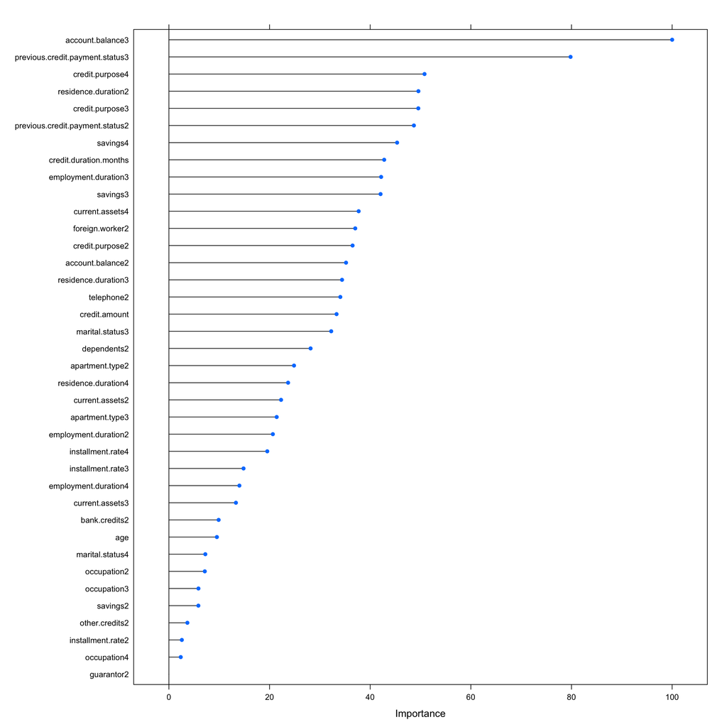

```r
controle_procedimento      <- trainControl(method = "repeatedcv", number = 10, repeats = 2)
modelo_ML_controle_traning <- train(equation, data = training_data, method = 'glm', trControl = controle_procedimento)
feature_selection = varImp(modelo_ML_controle_traning, scale = TRUE)
plot(feature_selection)
```

10. Obtenha a curva ROC do classificador antes da análise varImp

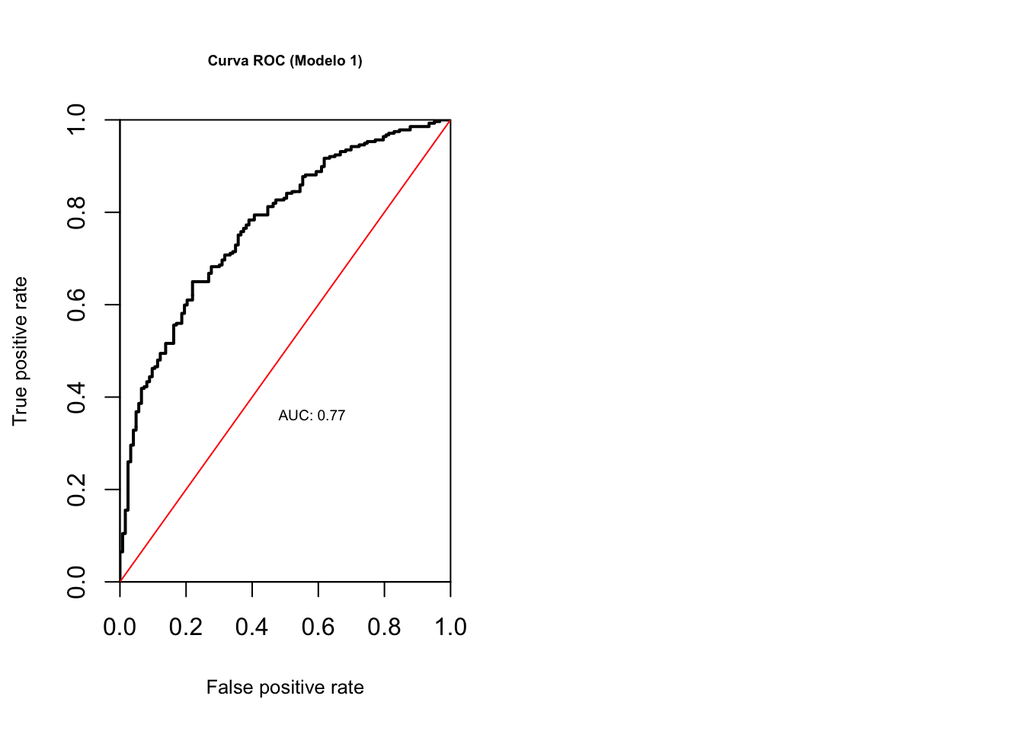

```r
previsao_teste_modelo_1 <- predict(modelo_ML_logistic_1, test_data, type = 'response')
previsoes_finais_modelo_1 <- prediction(previsao_teste_modelo_1, test_target)

plot.roc.curve <- function(predictions, title.text){
  perf <- performance(predictions, "tpr", "fpr")
  plot(perf,col = "black",lty = 1, lwd = 2,
       main = title.text, cex.main = 0.6, cex.lab = 0.8,xaxs = "i", yaxs = "i")
  abline(0,1, col = "red")
  auc <- performance(predictions,"auc")
  auc <- unlist(slot(auc, "y.values"))
  auc <- round(auc,2)
  legend(0.4,0.4,legend = c(paste0("AUC: ",auc)), cex = 0.6, bty = "n", box.col = "white")
}

par(mfrow = c(1, 2))
plot.roc.curve(previsoes_finais_modelo_1, title.text = "Curva ROC (Modelo 1)")
```

11. Obtenha a curva ROC do classificador após da análise com varImp

```r
equation_nova <- "credit.rating ~ account.balance + credit.purpose + previous.credit.payment.status + savings + credit.duration.months"

equation_nova <- as.formula(equation_nova)
modelo_ML_logistic_2 <- glm(equation_nova, data = training_data, family = "binomial")
modelo_ML_logistic_2
```

```
##
## Call:  glm(formula = equation_nova, family = "binomial", data = training_data)
##
## Coefficients:
##                     (Intercept)                 account.balance2
##                        -0.40988                          0.59469
##                account.balance3                  credit.purpose2
##                         1.61365                         -0.92602
##                 credit.purpose3                  credit.purpose4
##                        -1.21800                         -1.21333
## previous.credit.payment.status2  previous.credit.payment.status3
##                         1.24322                          1.93948
##                        savings2                         savings3
##                         0.01982                          0.85402
##                        savings4           credit.duration.months
##                         0.85490                         -0.51774
##
## Degrees of Freedom: 599 Total (i.e. Null);  588 Residual
## Null Deviance:       727.9
## Residual Deviance: 575.1     AIC: 599.1
```

```r
summary(modelo_ML_logistic_2)
```

```
##
## Call:
## glm(formula = equation_nova, family = "binomial", data = training_data)
##
## Deviance Residuals:
##     Min       1Q   Median       3Q      Max
## -2.5313  -0.7150   0.4424   0.7281   1.9486
##
## Coefficients:
##                                 Estimate Std. Error z value Pr(>|z|)
## (Intercept)                     -0.40988    0.53310  -0.769 0.441968
## account.balance2                 0.59469    0.25844   2.301 0.021386 *
## account.balance3                 1.61365    0.25928   6.224 4.86e-10 ***
## credit.purpose2                 -0.92602    0.47275  -1.959 0.050137 .
## credit.purpose3                 -1.21800    0.44301  -2.749 0.005971 **
## credit.purpose4                 -1.21333    0.44572  -2.722 0.006485 **
## previous.credit.payment.status2  1.24322    0.35512   3.501 0.000464 ***
## previous.credit.payment.status3  1.93948    0.37900   5.117 3.10e-07 ***
## savings2                         0.01982    0.34028   0.058 0.953561
## savings3                         0.85402    0.37739   2.263 0.023638 *
## savings4                         0.85490    0.31073   2.751 0.005936 **
## credit.duration.months          -0.51774    0.10830  -4.780 1.75e-06 ***
## ---
## Signif. codes:  0 '***' 0.001 '**' 0.01 '*' 0.05 '.' 0.1 ' ' 1
##
## (Dispersion parameter for binomial family taken to be 1)
##
##     Null deviance: 727.88  on 599  degrees of freedom
## Residual deviance: 575.06  on 588  degrees of freedom
## AIC: 599.06
##
## Number of Fisher Scoring iterations: 5
```

```r
previsao_teste_2 <- predict(modelo_ML_logistic_2, test_data, type = 'response')
previsao_teste_2 <- round(previsao_teste_2)
previsao_teste_2_data <- data.frame(previsao_teste_2, test_target)
colnames(previsao_teste_2_data) <- c('Previsão Nova','Target')
```

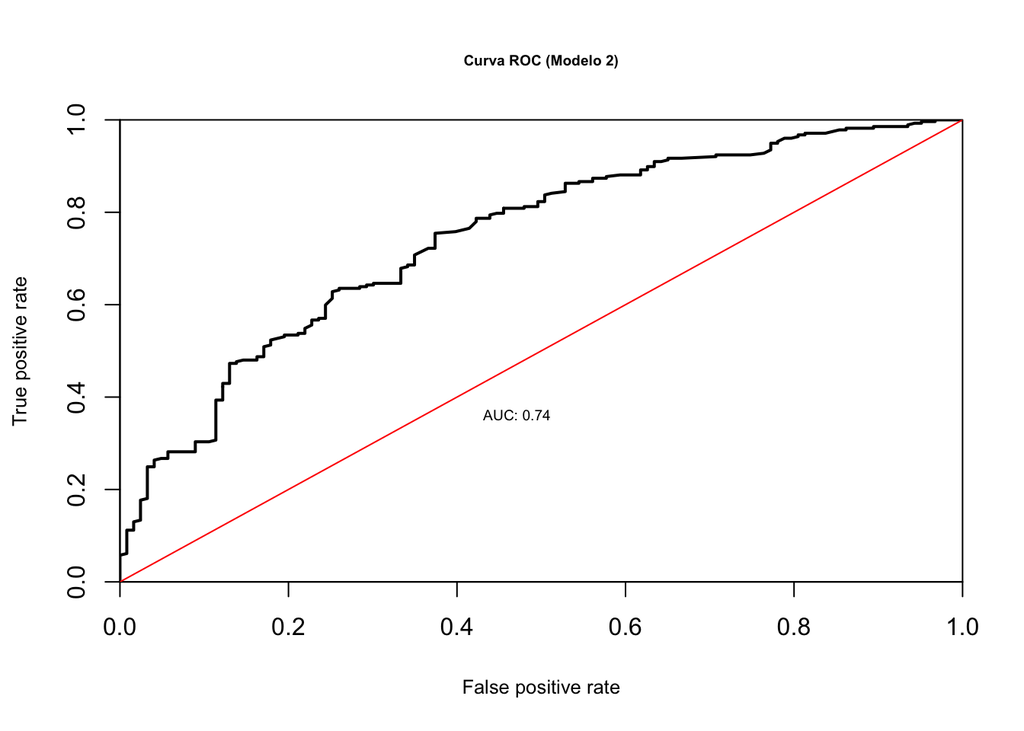

```r
cm_modelo_2 <- confusionMatrix(table(data = previsao_teste_2, reference = test_target), positive = "1")
previsao_teste_modelo_2 <- predict(modelo_ML_logistic_2, test_data, type = 'response')
previsoes_finais_modelo_2 <- prediction(previsao_teste_modelo_2, test_target)

plot.roc.curve <- function(predictions, title.text){
  perf <- performance(predictions, "tpr", "fpr")
  plot(perf,col = "black",lty = 1, lwd = 2,
       main = title.text, cex.main = 0.6, cex.lab = 0.8,xaxs = "i", yaxs = "i")
  abline(0,1, col = "red")
  auc <- performance(predictions,"auc")
  auc <- unlist(slot(auc, "y.values"))
  auc <- round(auc,2)
  legend(0.4,0.4,legend = c(paste0("AUC: ",auc)), cex = 0.6, bty = "n", box.col = "white")
}

plot.roc.curve(previsoes_finais_modelo_2, title.text = "Curva ROC (Modelo 2)")
```